# Lendo os Dados

Ícaro Vidal Freire

Parte II

## Antes de começarmos …

Antes da “leitura” dos dados, é importante organizarmos nosso projeto.

Aconselhei criar uma pasta em “Meus Documentos” com o nome “projetos_em_R”. Nessa pasta colocaremos todas nossas análises feitas com o `R`.

Então, dentro da pasta “projetos_em_R” vamos criar nosso diretório de trabalho, que nada mais é do que uma outra pasta com o nome do projeto que estamos realizando.

Para essa análise, vamos denominar `tidyverse_readr`. Então, de uma forma geral, teríamos algo assim:

```r
.
└── projetos_em_R/
    └── tidyverse_readr/
```

Para criarmos isso, vamos usar o pacote `usethis` (que já deveria estar previamente instalado)[^1]. Esses são os passos:

1. Abra o R Studio;
2. No Console, digite: `usethis::create_project("projetos_em_R/tidyverse_readr")`
3. Dê *Enter*.

Depois de um *Checklist* interno, abrirá uma nova seção do R Studio (você pode fechar a anterior). A imagem fica mais ou menos assim:

[figure not shown]

```
.
└── tidyverse_readr/
    ├── .gitignore
    ├── R/
    └── tidyverse.Rproj
```

É uma boa prática criarmos uma pasta para colocarmos os **dados brutos** (*raw*, em inglês) e os **dados arrumados** (*tidy*).

Então, seu diretório de trabalho deve conter, pelo menos, uma estrutura assim:

```r
.
└── tidyverse_readr/     # diretório do projeto atual
    ├── .gitignore       # arquivo para ignorar versionamentos em alguns casos
    ├── dados/           # diretório dos datasets
    │   ├── brutos/      # dataset "bruto"
    │   └── tidy/        # dataset "arrumado"
    ├── R/               # diretório para salvar os `scripts` em R
    └── tidyverse.Rproj  # arquivo que abre o seu projeto no R Studio
```

Você pode fazer isso clicando com o botão direito do *mouse* dentro do diretório “tidyverse_readr” e criar as pastas, renomeando-as; ou usar, mais uma vez, o pacote `usethis`, com a função `use_directory()`, da seguinte forma:

- `usethis::use_directory("dados"))`, para criar o diretório “dados”;
- `usethis::use_directory("dados/brutos")`, para criar a subpasta “brutos”, dentro do diretório “dados”;
- `usethis::use_directory("dados/tidy")`, para criar a subpasta “tidy”, dentro do diretório “dados”.

Alternativamente, você pode pode criar esses diretórios de uma única vez com o comando[^2]:

```r
usethis::use_directory(c("dados/brutos", "dados/tidy"))
```

Quando o número de *datasets* são elvados, alguns ainda organizam em subpastas os arquivos `.csv`, `.xlsx`, etc., dessa forma:

```
.
└── tidyverse_readr/
    ├── .gitignore
    ├── dados/
    │   ├── brutos/
    │   │   ├── csv/
    │   │   ├── xlsx/
    │   │   └── ...
    │   └── tidy/
    ├── R/
    └── tidyverse.Rproj
```

Essa última organização não utilizaremos, por conta de nossos fins (usaremos um exemplo de cada, o que não causaria confusão colocando-os na mesmo diretório/pasta)[^3]

Feita a organização de seu diretório de trabalho, vamos endender um pouco mais sobre o pacote `readr`.

## Mostre-me os dados!

Para que aconteça uma análise de dados, certamente precisamos de uma *base de dados*. O computador deve acessar e processar tais dados de forma correta.

Existem muitos formatos de dados, mas interessa-nos aqueles em formato de *data frame*, ou melhor, *tibble*, em que as colunas reprentam variáveis.

Mas, existem muitas formas de escrever uma *tibble*. Podemos separar suas colunas por **vírgulas** (“,”); **espaços** (" “); **ponto e vírgula** (”;“); **barras verticais** (”|"); dentre muitos outras. E o `R` possui funções e pacotes específicos para cada um deles.

Por exemplo, se escrevermos em um *bloco de notas* o texto a seguir:

```
Nome, Curso, Nota
Zeca, Matemática, 9.7
Asponjo, Matemática, 9.8
Teco, Química, 7.0
Titica, Química, 9.7
Astrobalda, Química, 9.0
```

E, depois, salvarmos com a extensão `.csv`; ao acessarmos adequadamente tal texto com o `R`, ele interpreta-o como uma “planilha” (*tibble*), assim:

```
## # A tibble: 5 x 3
##   Nome       Curso       Nota
##   <chr>      <chr>      <dbl>
## 1 Zeca       Matemática   9.7
## 2 Asponjo    Matemática   9.8
## 3 Teco       Química      7
## 4 Titica     Química      9.7
## 5 Astrobalda Química      9
```

Para “leitura” desses dados, o `R Base` possui, por exemplo, uma familia de as funções `read.xxx`, onde `xxx` representa diversas extenções (`csv`, `csv2`, `fortran`, etc.). São proeminentes as funções: - `read.csv()`. Ela basicamente processa arquivos no formato `.csv` (*comma-separated-values*, ou seja, **valores separados por vírgula**); - `read.csv2()`. Processa arquivos separados por **ponto e vírgula**.

O `tidyverse` possui funções equivalentes à essas duas: - `read_csv()`, para ler arquivos separados por vírgulas - `read_csv2()`, para ler aquivos separados por ponto e vírgula.

As funções do `tidyverse` retornam uma *tibble*, enquanto as funções do `R Base` retornam um *data frame*. Uma não é melhor do que a outra! Cada uma pode ser usada em aspectos distinto. Embora as funções do `tidyverse` sejam contruídas com certas melhorais, em alguns casos exigem muito da memória do computador, mesmo em um banco de dados relatuvamente pequeno ( 500 Mb a 3 Gb)[^4] e, muitas vezes, precisamos recorrer às funções do `R Base`.

Mas, nesse curso, vamos usar apenas as funções listadas do `tidyverse`. Qual das duas usaremos? Aí dependerá de nossos dados. No exemplo citado acima, separamos as colunas por *vírgulas* e usamos o **ponto** como separador decimal. Nesse caso, usamos a função `read_csv()`. Mas, se as colunas fossem separadas por *ponto e vírgula* e a **vírgula** fosse o separador de decimais (que é o caso mais comum aqui no Brasil), usaríamos a função `read_csv2()`. A boa notícia é que ambas possuem a mesma estrutura de argumentos; e, por conta disso, vamos usar a `read_csv()` como explanação da teoria.

## Mas, como fazemos?

Primeiro de tudo é carregar o pacote [**readr**](https://readr.tidyverse.org/):

```r
library(readr)
```

Mas, como geralmete não ficamos apenas no carregamento de dados, mas na manipulação e análise, é usual carregarmos o pacote `tidyverse`:

```r
library(tidyverse)
```

Para exemplificação, consideremos um conjunto de dados denominado [`gordura_corporal.csv`](https://github.com/icaro-freire/dados_csv/blob/main/dados/tidy_csv/gordura_corporal.csv)[^5], que se encontrará dentro do diretório `brutos`, como estabelecemos no início:

```
.
└── tidyverse_readr/
    ├── .gitignore
    ├── dados/
    │   ├── brutos/
    │   │   └── gordura_corporal.csv
    │   └── tidy/
    ├── R/
    └── tidyverse.Rproj
```

A função `read_csv()` possui uma estrutura, mais ou menos assim:

```
read_csv("arquivo", arg-1, arg-2, ..., arg-n)
```

Em “arquivo”, colocamos (entre aspas) o caminho, junto com o nome do arquivo (incluindo sua extensão). Sobre os argumentos “arg-1”, “arg-2”, etc. falaremos oportunamente depois. Assim:

```r
read_csv("dados/brutos/gordura_corporal.csv")
```

Obviamente, se você não organizar seus dados em uma pasta (o que não é aconselhável), mas deixá-los no diretório original, basta fazer:

```r
read_csv("gordura_corporal.csv")
```

A saída, no console, fica assim:

```
## # A tibble: 100 x 10
##    indice_gordura idade  peso altura pescoco peito abdomen tornozelo biceps
##             <dbl> <dbl> <dbl>  <dbl>   <dbl> <dbl>   <dbl>     <dbl>  <dbl>
##  1           32.3    41  247.   73.5    42.1 117     116.       26.3   37.3
##  2           22.5    31  177.   71.5    36.2 101.     92.4      24.6   30.1
##  3           22      42  156.   69      35.5  97.8    86        24     31.2
##  4           12.3    23  154.   67.8    36.2  93.1    85.2      21.9   32
##  5           20.5    46  177    70      37.2  99.7    95.6      22.5   29.1
##  6           22.6    54  198    72      39.9 108.    100        22     35.9
##  7           28.7    43  200.   71.5    37.9 107.    103.       23.7   32.1
##  8           21.3    42  163    70.2    35.3  93.5    89.6      21.9   30.7
##  9           29.9    37  241.   71.5    42.1 119.    110.       24.8   34.4
## 10           21.3    41  218.   71      39.8 112.    100.       25.2   37.5
## # ... with 90 more rows, and 1 more variable: pulso <dbl>
```

É importante salvarmos essa `tibble` em uma variável par que possamos acessá-la na memória do computador e manipularmos em outras etapas. Vou nomear com o mesmo nome do arquivo. Logo,

```r
gordura_corporal <- read_csv("dados/brutos/gordura_corporal.csv")
```

Note que a forma acima, apenas ler e salva os dados na variável `gordura_corporal`, mas não o exibe. Se é a visualização que se deseja, então, no **console**, é preciso fazer:

```r
gordura_corporal <- read_csv("dados/brutos/gordura_corporal.csv")
gordura_corporal
```

Há uma forma que une essas duas etapas: colocar entre parênteses. Assim:

```r
( gordura_corporal <- read_csv("dados/brutos/gordura_corporal.csv") )
```

Porém, particularmente, uso a função `view()`[^6], do pacote `tibble` para “visualizar” a `tibble` de forma mais ampla e organizada.

```r
gordura_corporal <- read_csv("dados/brutos/gordura_corporal.csv")
view(gordura_corporal)
```

Ou, usando o operador *pipe*:

```r
gordura_corporal <- read_csv("dados/brutos/gordura_corporal.csv")

gordura_corporal %>%
  view()
```

O *script* final ficaria assim:

```r
# Carregando o pacote tidyverse
library(tidyverse)

# Lendo e salvando os dados
gordura_corporal <- read_csv("dados/brutos/gordura_corporal.csv")

# Visualizando os dados de forma geral
gordura_corporal %>% view()
```

## E se for uma planilha do Excel?

Para leitura de arquivos no formato `.xlsx`, usamos um pacote, do `tidyverse`, denominado: [readxl](https://readxl.tidyverse.org/).

A ideia e estrutura são as mesmas, mas o nome da função é `read_excel()`.

Lembre-se de carregar a biblioteca `readxl`, previamente. Um exemplo de *script* pode ser visto abaixo:

```r
# Carregando os pacotes
library(tidyverse)
library(readxl)

# Lendo e salvando os dados
nome_adequado <- read_excel("dados/brutos/nome-do-arquivo.xlsx")

# Visualizando o arquivo
nome_adequado %>% view()
```

## Uma outra forma de importar dados

Nem sempre os arquivos são organizados adequadamente numa planilha, causando erros de codificação, erros de leitura, etc.

Por conta disso, aconselho a importação do conjunto de dados, diretamente do R Studio.

Como fazemos isso?

1. No R Studio, observe o 4º quadrande, ou seja, o nicho dos *Files, Plots, Packages*, etc;
2. Selecione a aba *Files*;
3. Vá até a pasta onde se encontra o arquivo que você deseja importar;
4. Clique em tal arquivo;
5. Selecione `Import Dataset...`

Abrirá, então, uma janela do R Studio, com uma visualização prévia de seu *dataset*, onde você poderá verificar se as variáveis estão corretamente relacionadas e, por fim, selecionar o código de incorporação para colá-lo em seu *script*.

Para exemplificar, vamos considerar um arquivo denominado `temperatura_cidades.xlsx` que, por hipósete, encontra-se-á no mesmo diretório `brutos`, da pasta `dados`.

```
.
└── tidyverse_readr/
    ├── .gitignore
    ├── dados/
    │   ├── brutos/
    │   │   ├── gordura_corporal.csv
    │   │   └── temperatura_cidades.xlsx
    │   └── tidy
    ├── R/
    └── tidyverse.Rproj
```

Depois de percorrer o caminho até onde se encontra o arquivo, clicar nele e selecionar `Import Dataset...`, aparecerá a imagem:

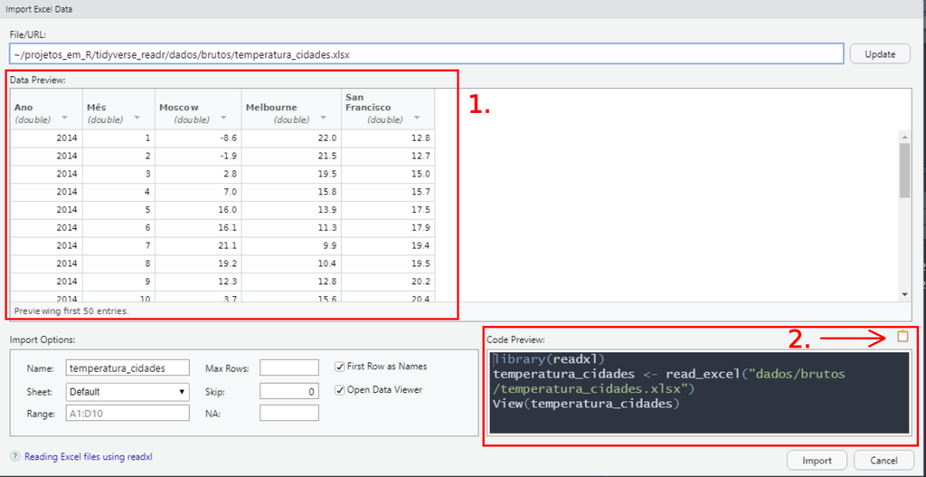

1. **Observe se as variáveis de seu conjunto de dados estão adequadas**. Nesse exemplo, a coluna “Ano” e “Mês” estão como variáveis quantitativas (no tidyverse,*double* - que é o mesmo que *numeric*, no R Base). Mas, nesse caso, estamos falando de “categorias”, ou “fatores” (de fato, mesmo que representemos pelos números $1, 2, 3, \ldots$, os meses são “janeiro”, “fevereiro”, etc.) (*character*). Assim, você poderia mudar a configuração das mesmas.
2. **Copie apenas o necessário**. No quadro 2, se você selecionar o ícone que a seta em vermelho aponta, copiará todo o código. Mas, se você já carregou os pacotes anteriormente, não é necessário carregar novamente. Além disso, a função `View()` é do `R Base`, você pode desmarcar a opção *Open Data Viewer*. Então, selecione apenas o que vor adequado.

A figura abaixo mostra a importação depois das mofificações das colunas citadas:

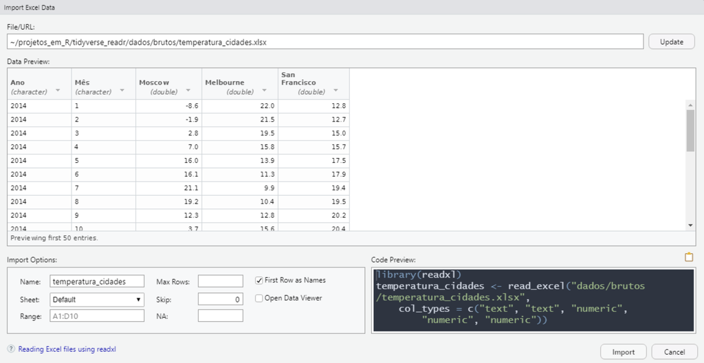

Selecionando o código modificado, temos:

```r
temperatura_cidades <- read_excel(
  "dados/brutos/temperatura_cidades.xlsx",
  col_types = c("text", "text", "numeric", "numeric", "numeric")
)
```

Observe que apareceu um novo argumento da função `read_excel()`, a saber, `col_types`. Esta, faz as mudanças adequadas nas variáveis escolhidas.

## Escrevendo seu *dataset*

Nem sempre é conveniente trabalhar com um *dataset* completo, se você só precisará de algumas de suas variáveis. Então, é uma boa prática, depois da limpeza dos dados, criar um arquivo `.csv` (que é o mais simples e libre de alguns erros de codificação) com exatamente aquilo que você deseja para sua análise.

O pacote `readr` fornece uma função para isso: a função `write_csv()`. Ela possui, mais ou menos, a seguinte estrutura:

```r
write_csv(dt, "caminho/novo-nome.csv", arg-1, arg-2, ..., arg-n)
```

Mais uma vez, os argumentos “arg-1”, “arg-2”, etc., serão, possivelmente, abordados oportunamente depois. Por hora, só necessitamos compreender o argumento “dt” e “novo-nome”.

Ora, `dt` é o *data tibble* que você fez a limpeza (ou, pelo menos, selecionou as variáveis para análise); e, `"novo-nome.csv"` é o novo nome que desejas dar ao arquivo. Neste último caso, deve conter a extensão `.csv` e estar **entre aspas**!.

Por exemplo, suponha que o nosso objetivo é escrever o *dataset* `temperatura_cidades.xlsx` para o formato `.csv`. Manteremos o mesmo nome, mas, apenas, modificaremos a extensão. Fica assim:

```r
write_csv(temperatura_cidades, "temperatura_cidades.csv")
```

Obviamente, essa função será mais explorada quando tratarmos da parte de manipulação de dados, assunto de próximos textos.

```
                                                    _
                                                   | |
                                 _ __ ___  __ _  __| |_ __
                                | '__/ _ \/ _` |/ _` | '__|
                                | | |  __/ (_| | (_| | |
                                |_|  \___|\__,_|\__,_|_|
```

[^1]: eu havia pedido para que vocês fizessem isso antes, mas caso não tenham feito, é só colocar no conlose do R Studio: `install.packages("usethis")`
[^2]: Veja que estamos criando a pasta “dados” e, dentro dela, mais duas: “brutos” e “tidy”. A barra `/` indica o caminho relativo.
[^3]: Para esse último exemplo, caso queira usar o `usethis` novamente, pode fazer assim: `usethis::use_directory(c("dados/brutos/csv", "dados/brutos/xlsx"))`
[^4]: quando o tamanho dos dados for realmente grande, ou seja, mais de 100 Gb, existem procedimentos e pacotes específicos para leitura adequada dos mesmos. Esses procedimentos estão em ascenssão atualmente e fazem parte de uma área chamada [“Big Data”](https://pt.wikipedia.org/wiki/Big_data)
[^5]: que dá a porcentagem de gordura corporal para 100 homens, usando variáveis como idade, peso (em libras), altura (em polegadas) e medidas de circunferência (em cm) para o pescoço, peito, abdômen, tornozelo, bíceps e punho. Pode-se usar: 1 libra = 0.45359 kg, bem como, 1 polegada = 2.54 cm
[^6]: há uma diferença entre `view()`, em minúscula; e `View()`, com primeira letra em maiúscula: a primeira é do pacote `tibble` e a segunda, do `R Base`